# ExtraaLearn Project

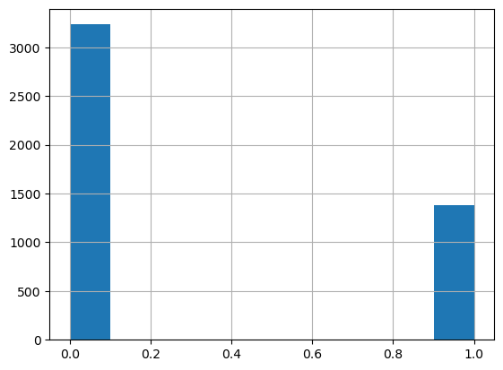

```python
Y.hist()
plt.show()
```

#### Observations:

The data has the same shape as before, which means that the scaling was correct and successful. It's not the case of the categorical variables, of course, since we created dummy variables to split the data.

## Building a Decision Tree model

```python
# Let´s build our decision tree model
dt = DecisionTreeClassifier(class_weight = {0:0.701431, 1:0.298569}, random_state = 1)
```

```python
# Let's fit it into our data
dt.fit(X_train_scaled, y_train)
```

```
DecisionTreeClassifier(class_weight={0: 0.701431, 1: 0.298569}, random_state=1)
```

```
              precision    recall  f1-score   support

           0       1.00      1.00      1.00      2264
           1       1.00      1.00      1.00       964

    accuracy                           1.00      3228
   macro avg       1.00      1.00      1.00      3228
weighted avg       1.00      1.00      1.00      3228
```

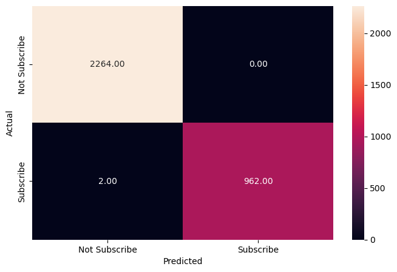

```python
# Now, let's test its performance on the training set
y_train_pred_dt = dt.predict(X_train_scaled)

metrics_score(y_train, y_train_pred_dt)
```

```
              precision    recall  f1-score   support

           0       0.86      0.85      0.86       971
           1       0.66      0.66      0.66       413

    accuracy                           0.80      1384
   macro avg       0.76      0.76      0.76      1384
weighted avg       0.80      0.80      0.80      1384
```

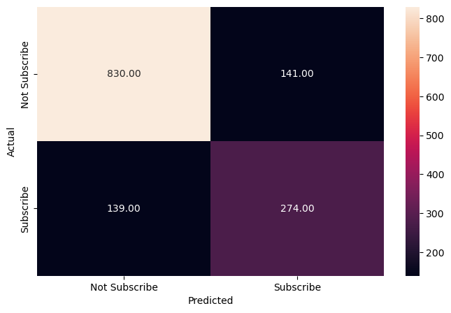

```python
# And now, let's test its performance on the test set
y_test_pred_dt = dt.predict(X_test_scaled)

metrics_score(y_test, y_test_pred_dt)
```

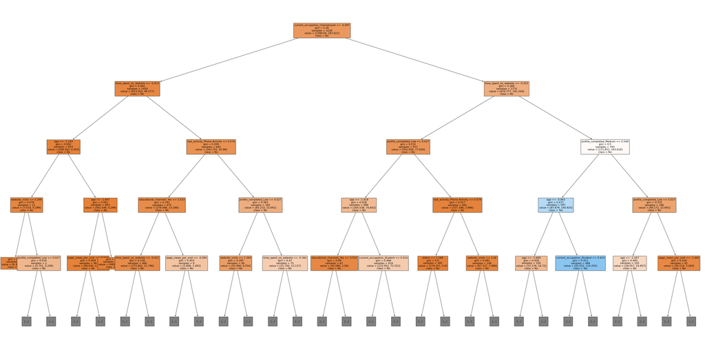

```python
# Let's plot our tree to have an idea of its shape
plt.figure(figsize = (60,30))
plot_tree(dt,max_depth=4, filled = True, fontsize = 12, feature_names = df.columns, class_names = ['No', 'Yes'])
plt.show()
```

#### Observations:

- The performance of the model on the train dataset is 100%, which is indicative of **overfitting**.
- Its **predictive power is quite bad**, failing to correctly predict positive cases almost a third of the times.
- Pruning the model is advised.

## Do we need to prune the tree?

Yes. We are going to prune it using Cost Complexity Pruning.

```python
# Firstly, we find the cost complexity of each node
path = dt.cost_complexity_pruning_path(X_train_scaled,y_train)
ccp_alphas, impurities = path.ccp_alphas, path.impurities

# Secondly, we determine the optimal pruning path
prun_trees = []
for ccp_alpha in ccp_alphas:
    tree = DecisionTreeClassifier(ccp_alpha=ccp_alpha)
    tree.fit(X_train_scaled,y_train)
    prun_trees.append(tree)

# Then we evaluate the performance of each tree
validation_scores = [tree.score(X_test_scaled, y_test) for tree in prun_trees]

# And take the optimal one
opt_tree = prun_trees[np.argmax(validation_scores)]
```

```python
# Let's refit the optimal tree
opt_tree.fit(X_train_scaled, y_train)
```

```
DecisionTreeClassifier(ccp_alpha=0.0012189113247403696)
```

```
              precision    recall  f1-score   support

           0       0.90      0.92      0.91      2264
           1       0.80      0.75      0.78       964

    accuracy                           0.87      3228
   macro avg       0.85      0.84      0.84      3228
weighted avg       0.87      0.87      0.87      3228
```

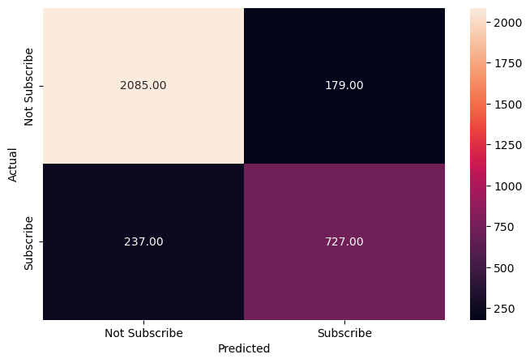

```python
# Now, let's test its performance on the training set
y_train_pred_dt = opt_tree.predict(X_train_scaled)

metrics_score(y_train, y_train_pred_dt)
```

#### Observations:

As we can see above, the model's performance for the training dataset has lowered considerably, but still keeping a good score. We successfully avoided overfitting.

```
              precision    recall  f1-score   support

           0       0.88      0.92      0.90       971
           1       0.80      0.71      0.75       413

    accuracy                           0.86      1384
   macro avg       0.84      0.82      0.83      1384
weighted avg       0.86      0.86      0.86      1384
```

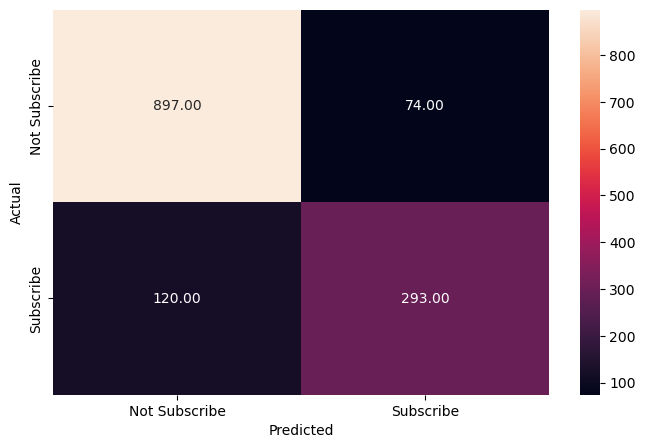

```python
# And now, let's test its performance on the test set
y_test_pred_dt = opt_tree.predict(X_test_scaled)

metrics_score(y_test, y_test_pred_dt)
```

#### Observations:

The **performance** of the model on the test dataset is **almost as good** as on the training set, only losing 2% on the precision of the negative cases and 4% on the recall of the positives. We successfully made a **pretty good model.**

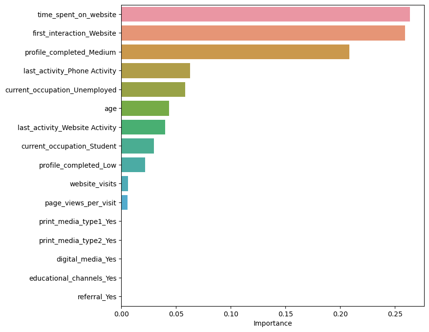

```python
# Now let's have a look at the importance of the variables,
# in order to extract insight and conclussions
importances = opt_tree.feature_importances_

columns = X.columns

importance_df = pd.DataFrame(importances, index = columns, columns = ['Importance']).sort_values(by = 'Importance', ascending = False)

plt.figure(figsize = (8, 8))

sns.barplot(importance_df.Importance,importance_df.index)
```

#### Observations:

- Three of the variables stand out from the others in importance: the **time spent on the website**, the **first interaction** and the **medium to high completeness of the user's profile**.
- Five of them have an importance of 0, which tells us that they're accessory and could be dropped without losing any performance.

## Building a Random Forest model

```python
# Let's fit the model on the training data
rf = RandomForestClassifier(class_weight = 'balanced', random_state = 1)

rf.fit(X_train_scaled, y_train)
```

```
RandomForestClassifier(class_weight='balanced', random_state=1)
```

```
              precision    recall  f1-score   support

           0       1.00      1.00      1.00      2264
           1       1.00      1.00      1.00       964

    accuracy                           1.00      3228
   macro avg       1.00      1.00      1.00      3228
weighted avg       1.00      1.00      1.00      3228
```

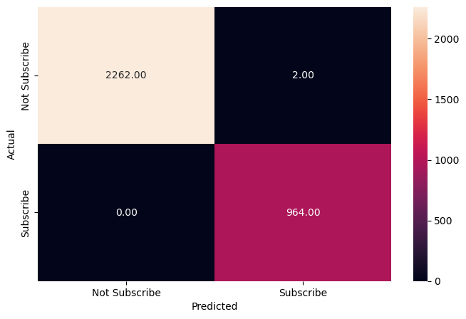

```python
# Now, let's test its performance on the training dataset
y_train_pred_rf = rf.predict(X_train_scaled)

metrics_score(y_train, y_train_pred_rf)
```

#### Observations:

The model has perfect performance on the training dataset.

```
              precision    recall  f1-score   support

           0       0.89      0.92      0.91       971
           1       0.80      0.73      0.76       413

    accuracy                           0.87      1384
   macro avg       0.85      0.83      0.84      1384
weighted avg       0.86      0.87      0.86      1384
```

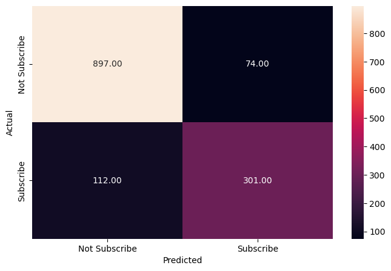

```python
# Now, let's test its performance on the test set
y_test_pred_rf = rf.predict(X_test_scaled)

metrics_score(y_test, y_test_pred_rf)
```

#### Observations:

- The overall performance of the random forest is slightly better than the performance of the decision tree we just made.
- It's a pretty good performance, except for the recall on the positive cases, which is the lowest of the indexes, but still pretty good.

## Do we need to prune the tree?

I would say **no**. The performance of the model is good enough.  
But, in any case, we are going to try using **feature selection** to see if the perfomance improves.

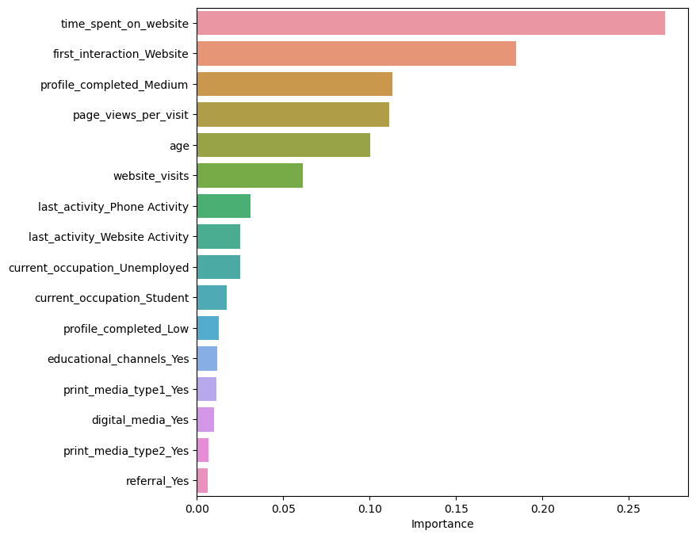

```python
# Now let's have a look at the importance of the variables,
# in order to extract insight and conclussions
importances = rf.feature_importances_

columns = X.columns

importance_rf = pd.DataFrame(importances, index = columns, columns = ['Importance']).sort_values(by = 'Importance', ascending = False)

plt.figure(figsize = (8, 8))

sns.barplot(importance_rf.Importance,importance_rf.index)
```

#### Observations:

- **Time spent on the website** has a huge impact on the model.
- The variables under **profile completed low** have a very small impact. Therefore, we are going to drop them from the dataset and build a new model, to see if the performance improves.

```python
# Let's create a new data frame that only contains important variables
drop_var = ['profile_completed_Low','print_media_type1_Yes', 'print_media_type2_Yes', 'digital_media_Yes', 'educational_channels_Yes', 'referral_Yes']
df_clean = df
for i in drop_var:
    df_clean = df_clean.drop([i], axis=1)
```

```python
# Let's split the data into a new X and Y
Y = df_clean.status
X = df_clean.drop(columns=['status'])
X_train, X_test, y_train, y_test = train_test_split(X, Y, test_size = 0.3, random_state = 1, stratify = Y)

# Now fit_transform on train data
X_train_scaled=sc.fit_transform(X_train)
X_train_scaled=pd.DataFrame(X_train_scaled, columns=X.columns)

# Finally, apply transform on test data
X_test_scaled=sc.transform(X_test)
X_test_scaled=pd.DataFrame(X_test_scaled, columns=X.columns)
```

```python
# Let's fit the model on the new training data
rf_clean = RandomForestClassifier(class_weight = 'balanced', random_state = 1)

rf_clean.fit(X_train_scaled, y_train)
```

```
RandomForestClassifier(class_weight='balanced', random_state=1)
```

```
              precision    recall  f1-score   support

           0       1.00      1.00      1.00      2264
           1       1.00      1.00      1.00       964

    accuracy                           1.00      3228
   macro avg       1.00      1.00      1.00      3228
weighted avg       1.00      1.00      1.00      3228
```

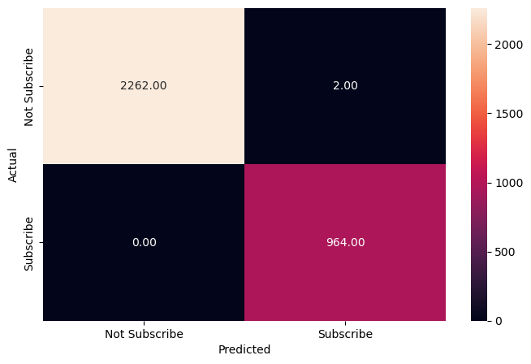

```python
# Let's test its performance on the training dataset
y_train_pred_rf = rf_clean.predict(X_train_scaled)

metrics_score(y_train, y_train_pred_rf)
```

#### Observations:

The model works at 100% on the training dataset.

```
              precision    recall  f1-score   support

           0       0.88      0.91      0.90       971
           1       0.77      0.72      0.74       413

    accuracy                           0.85      1384
   macro avg       0.83      0.81      0.82      1384
weighted avg       0.85      0.85      0.85      1384
```

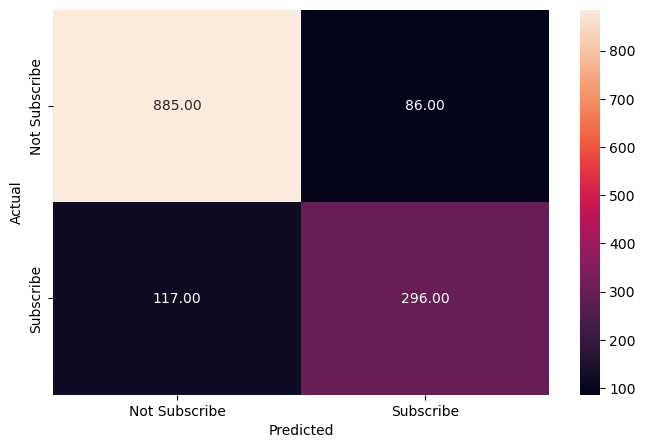

```python
# Now, let's test its performance on the test set
y_test_pred_rf = rf_clean.predict(X_test_scaled)

metrics_score(y_test, y_test_pred_rf)
```

#### Observations:

The performance of the model has been reduced slighlty (1-3%), which means that **we didn't need to drop those features.**

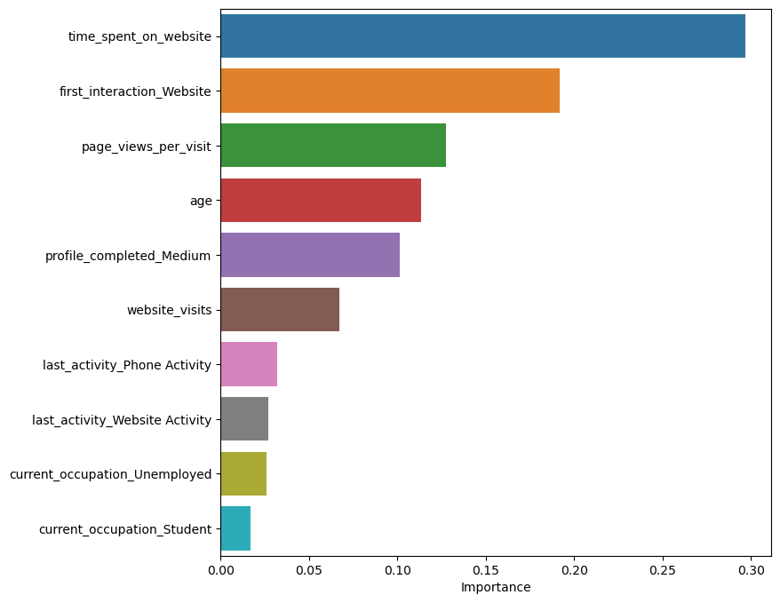

```python
importances = rf_clean.feature_importances_

columns = X.columns

importance_rf = pd.DataFrame(importances, index = columns, columns = ['Importance']).sort_values(by = 'Importance', ascending = False)

plt.figure(figsize = (8, 8))

sns.barplot(importance_rf.Importance,importance_rf.index)
```

#### Observations:

After dropping the least important features, the order and magnitude of some of the present features has changed slightly.